# Weather and Corn Yield Regressions

### Question 1b

Fit a quadratic time trend (i.e., year + year^2) and make a plot. Is there evidence for slowing yield growth?

```r
winneYieldLin<- lm(yield ~ year, winneYield)
summary(winneYieldLin)
```

```
##
## Call:
## lm(formula = yield ~ year, data = winneYield)
##
## Residuals:
##     Min      1Q  Median      3Q     Max
## -51.163  -1.841   2.363   9.437  24.376
##
## Coefficients:
##              Estimate Std. Error t value Pr(>|t|)
## (Intercept) -4763.290    448.286  -10.63 4.46e-13 ***
## year            2.457      0.224   10.96 1.77e-13 ***
## ---
## Signif. codes:  0 '***' 0.001 '**' 0.01 '*' 0.05 '.' 0.1 ' ' 1
##
## Residual standard error: 16.97 on 39 degrees of freedom
## Multiple R-squared:  0.7551, Adjusted R-squared:  0.7488
## F-statistic: 120.2 on 1 and 39 DF,  p-value: 1.767e-13
```

```r
winneYield$lin <- winneYieldLin$fitted.values


winneYield$yearSq <- winneYield$year^2
winneYieldQuad<- lm(yield ~ year + yearSq, winneYield)
summary(winneYieldQuad)
```

```
##
## Call:
## lm(formula = yield ~ year + yearSq, data = winneYield)
##
## Residuals:
##     Min      1Q  Median      3Q     Max
## -51.384  -3.115   1.388   9.743  25.324
##
## Coefficients:
##               Estimate Std. Error t value Pr(>|t|)
## (Intercept)  2.583e+04  8.580e+04   0.301    0.765
## year        -2.812e+01  8.576e+01  -0.328    0.745
## yearSq       7.641e-03  2.143e-02   0.357    0.723
##
## Residual standard error: 17.17 on 38 degrees of freedom
## Multiple R-squared:  0.7559, Adjusted R-squared:  0.7431
## F-statistic: 58.84 on 2 and 38 DF,  p-value: 2.311e-12
```

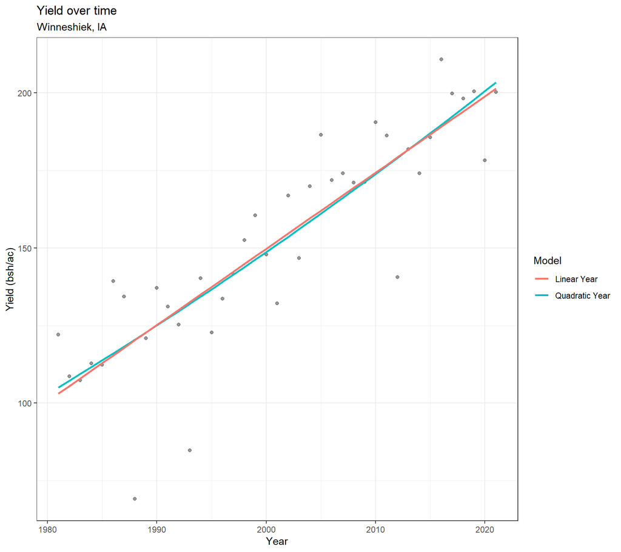

```r
winneYield$quad <- winneYieldQuad$fitted.values

ggplot(winneYield) +
  geom_point(mapping = aes(x = year, y = yield), alpha = 0.4, colour = "black") +
  geom_line(mapping = aes(x = year, y = quad, col='Quadratic Year'), size=1) +
  geom_line(mapping = aes(x = year, y = lin, col='Linear Year'), size=1) +
  theme_bw() +
  labs(x = "Year", y = "Yield (bsh/ac)", title= "Yield over time", subtitle="Winneshiek, IA", color = "Model")
```

### Interpretation

There is no evidence of slowing corn yield growth in Winneshiek County, IA. The slope of the quadratic time model is relatively constant over time, if anything there is slight acceleration.

## Question 2 – Time Series

Let’s analyze the relationship between temperature and yields for the Winneshiek County time series. Use data on **yield** and **summer avg Tmax**. Is adding year or Tmax^2 to your model helpful? Make a plot and interpret the results.

```r
winneYieldTemp = merge(winneYield, winneSummer, by = 'year') %>%
  mutate(
    yieldSq = yield^2,
    meanTmaxSq = meanTmax^2
  )
```

```r
winneYieldTempLin<- lm(yield ~ meanTmax, winneYieldTemp)
winneYieldTemp$tempLin <- winneYieldTempLin$fitted.values

winneYieldTempQuad<- lm(yield ~ meanTmax + meanTmaxSq, winneYieldTemp)
winneYieldTemp$tempQuad <- winneYieldTempQuad$fitted.values

winneYieldYearLinTempLin<- lm(yield ~ meanTmax + year, winneYieldTemp)
winneYieldTemp$yearTempLin <- winneYieldYearLinTempLin$fitted.values

winneYieldYearTempQuad<- lm(yield ~ year + yearSq + meanTmax + meanTmaxSq, winneYieldTemp)
#summary(winneYieldYearTempQuad$coefficients)
winneYieldTemp$yearTempQuad <- winneYieldYearTempQuad$fitted.values
```

```r
plot_win_temp =  ggplot(winneYieldTemp) +
  geom_point(mapping = aes(x = meanTmax, y = yield), alpha = 1, colour = "black") +
  geom_line(mapping = aes(x = meanTmax, y = tempQuad, col="Quadratic Temp"), size=1) +
  geom_line(mapping = aes(x = meanTmax, y = tempLin, col="Linear Temp"), size=1) +
  geom_line(mapping = aes(x = meanTmax, y = yearTempLin, col="Linear Temp Year"), size=1) +
  geom_line(mapping = aes(x = meanTmax, y = yearTempQuad, col="Quadratic Temp Year "), size=1) +
  theme_bw() +
  labs(x = "T Max (°C)", y = "Yield (bsh/ac)", title= "Yield over T Max", subtitle="Winneshiek, IA", color = "Model")

plot_win_yield=  ggplot(winneYieldTemp) +
  geom_point(mapping = aes(x = year, y = yield), alpha = 1, colour = "black") +
  geom_line(mapping = aes(x = year, y = tempQuad, col="Quadratic Temp"), size=1) +
  geom_line(mapping = aes(x = year, y = tempLin, col="Linear Temp"), size=1) +
  geom_line(mapping = aes(x = year, y = yearTempLin, col="Linear Temp & Year"), size=1) +
  geom_line(mapping = aes(x = year, y = yearTempQuad, col="Quadratic Temp & Year "), size=1) +
  theme_bw() +
  labs(x = "Year", y = "Yield (bsh/ac)", title= "Yield over time", subtitle="Winneshiek, IA", color = "Model")
```

### Interpretation

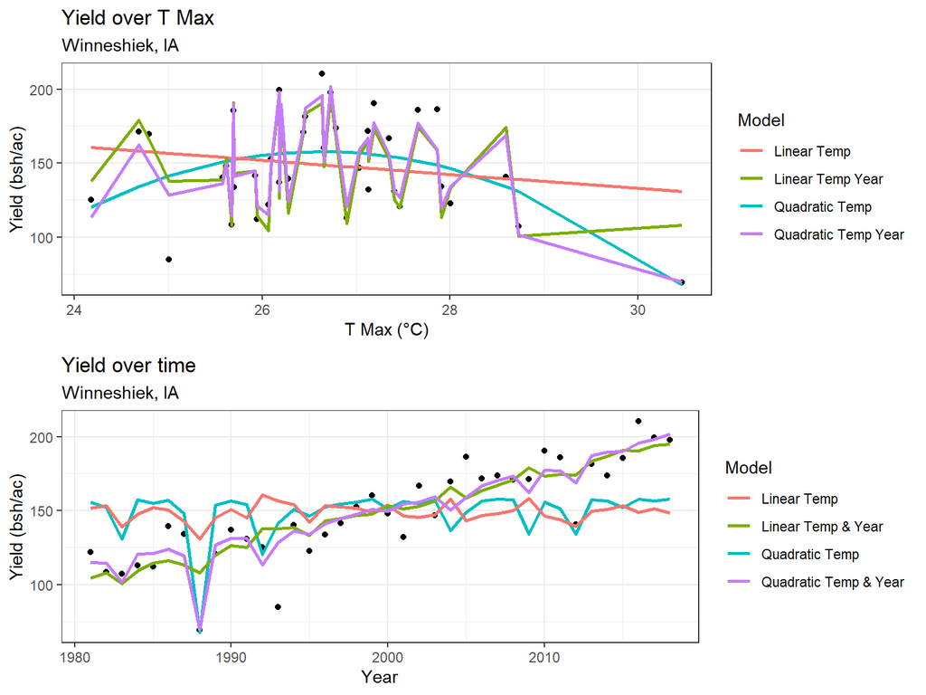

```r
grid.arrange(
  plot_win_temp,
  plot_win_yield
)
```

```r
summary(winneYieldYearTempQuad)
```

```
##
## Call:
## lm(formula = yield ~ year + yearSq + meanTmax + meanTmaxSq, data = winneYieldTemp)
##
## Residuals:
##     Min      1Q  Median      3Q     Max
## -43.488  -5.935   0.565   9.052  27.192
##
## Coefficients:
##               Estimate Std. Error t value Pr(>|t|)
## (Intercept)  7.437e+04  8.687e+04   0.856 0.398150
## year        -7.929e+01  8.684e+01  -0.913 0.367834
## yearSq       2.041e-02  2.172e-02   0.940 0.354109
## meanTmax     2.050e+02  5.323e+01   3.850 0.000514 ***
## meanTmaxSq  -3.856e+00  9.845e-01  -3.916 0.000426 ***
## ---
## Signif. codes:  0 '***' 0.001 '**' 0.01 '*' 0.05 '.' 0.1 ' ' 1
##
## Residual standard error: 14.29 on 33 degrees of freedom
## Multiple R-squared:  0.8322, Adjusted R-squared:  0.8118
## F-statistic:  40.9 on 4 and 33 DF,  p-value: 2.394e-12
```

## Question 3 – Cross-Section

Analyze the relationship between temperature and yield across all counties in 2018. Is there a relationship? Interpret the results.

```r
tmaxAll = tmaxdf %>%
  filter(doy >= 152 & doy <= 243) %>%
  group_by(year, countyfp) %>%
  summarize(meanTmax = mean(tmax))
iowa = merge(cornyields, tmaxAll, by.x=c("year", "county_ansi"), by.y=c("year", "countyfp")) %>%
  mutate(
    yearSq = year^2,
    yieldSq = yield^2,
    meanTmaxSq = meanTmax ^ 2
  )

iowa2018 = iowa %>%
  filter(year == 2018)
```

```r
iowa2018YieldTempLin<- lm(yield ~ meanTmax, iowa2018)
#summary(iowa2018YieldTempLin)
iowa2018$lin <- iowa2018YieldTempLin$fitted.values

iowa2018YieldTempQuad<- lm(yield ~ meanTmax + meanTmaxSq, iowa2018)
#summary(iowa2018YieldTempQuad)
iowa2018$quad <- iowa2018YieldTempQuad$fitted.values
```

### Interpretation

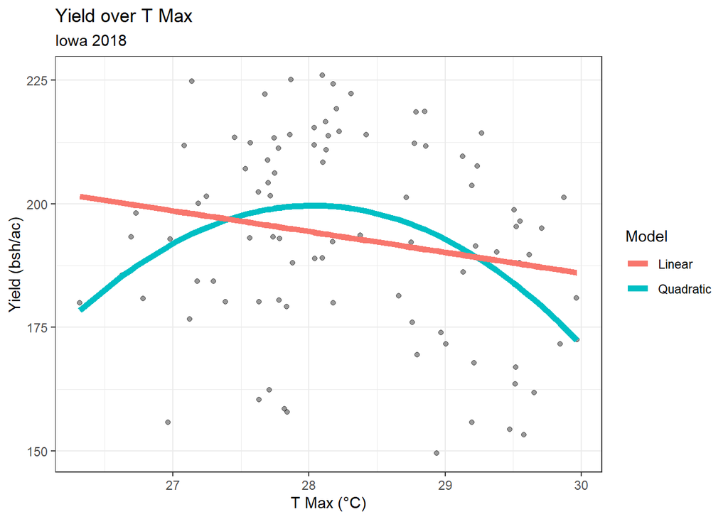

```r
ggplot(iowa2018) +
  geom_point(mapping = aes(x = meanTmax, y = yield), alpha = 0.4, colour = "black") +
  geom_line(mapping = aes(x = meanTmax, y = quad, colour="Quadratic"), size=2) +
  geom_line(mapping = aes(x = meanTmax, y = lin, colour="Linear"), size=2) +
  theme_bw() +
  labs(x = "T Max (°C)", y = "Yield (bsh/ac)", title= "Yield over T Max", subtitle="Iowa 2018", color = "Model")
```

```r
summary(iowa2018YieldTempQuad)
```

```
##
## Call:
## lm(formula = yield ~ meanTmax + meanTmaxSq, data = iowa2018)
##
## Residuals:
##     Min      1Q  Median      3Q     Max
## -44.221 -15.399   5.007  14.541  30.879
##
## Coefficients:
##              Estimate Std. Error t value Pr(>|t|)
## (Intercept) -5501.602   1860.830  -2.957  0.00397 **
## meanTmax      406.789    131.493   3.094  0.00263 **
## meanTmaxSq     -7.256      2.321  -3.126  0.00239 **
## ---
## Signif. codes:  0 '***' 0.001 '**' 0.01 '*' 0.05 '.' 0.1 ' ' 1
##
## Residual standard error: 18.75 on 90 degrees of freedom
## Multiple R-squared:  0.1317, Adjusted R-squared:  0.1124
## F-statistic: 6.827 on 2 and 90 DF,  p-value: 0.001736
```

## Question 4 – Panel

One way to leverage multiple time series is to group all data into what is called a “panel” regression. Convert the county ID code (“countyfp” or “county_ansi”) into factor using as.factor, then *include this variable in a regression using all counties’ yield and summer temperature data*. How does the significance of your temperature coefficients (Tmax, Tmax^2) change? Make a plot comparing actual and fitted yields and interpret the results of your model.

```r
# add factors
iowa$county_name = as.factor(iowa$county_name)
iowa$county_ansi = as.factor(iowa$county_ansi)
```

```r
# Single Factor Models
iowa_TempQuad = lm(yield ~ meanTmax + meanTmaxSq, iowa)
#summary(iowa_TempQuad)
iowa$m_tempSq <- iowa_TempQuad$fitted.values

iowa_YearQuad = lm(yield ~ year + yearSq, iowa)
#summary(iowa_YearQuad)
iowa$m_yearSq <- iowa_YearQuad$fitted.values

iowa_County = lm(yield ~ county_name, iowa)
#summary(iowa_County)
iowa$m_county <- iowa_County$fitted.values

iowa_Combined = lm(yield ~ year + yearSq + meanTmax + meanTmaxSq + county_name, iowa)
#summary(iowa_Combined)
iowa$m_combined <- iowa_Combined$fitted.values
```

### Interpretation

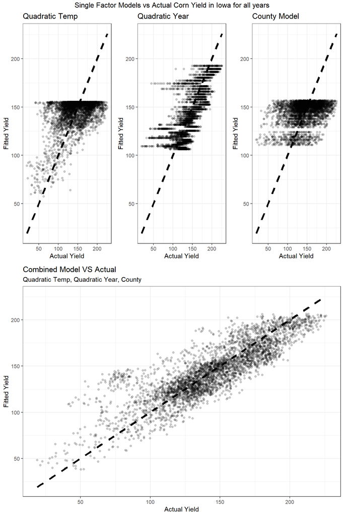

```r
grid.arrange(
top = "Single Factor Models vs Actual Corn Yield in Iowa for all years",
layout_matrix = rbind(c(1, 2, 3),c(4, 4, 4)),

ggplot(iowa) +
  geom_point(mapping = aes(x = yield, y = m_tempSq), alpha = 0.2) +
  geom_line(mapping = aes(x = yield, y = yield), linetype = "dashed", size=1.5) +
  theme_bw() +
  labs(x = "Actual Yield", y = "Fitted Yield", title= "Quadratic Temp",)
,
ggplot(iowa) +
  geom_point(mapping = aes(x = yield, y = m_yearSq), alpha = 0.2) +
  geom_line(mapping = aes(x = yield, y = yield), linetype = "dashed", size=1.5) +
  theme_bw() +
  labs(x = "Actual Yield", y = "Fitted Yield", title= "Quadratic Year")
,
ggplot(iowa) +
  geom_point(mapping = aes(x = yield, y = m_county), alpha = 0.2) +
  geom_line(mapping = aes(x = yield, y = yield), linetype = "dashed", size=1.5) +
  theme_bw() +
  labs(x = "Actual Yield", y = "Fitted Yield", title= "County Model")
,
ggplot(iowa) +
  geom_point(mapping = aes(x = yield, y = m_combined), alpha = 0.2) +
  geom_line(mapping = aes(x = yield, y = yield), linetype = "dashed", size=1.5) +
  theme_bw() +
  labs(x = "Actual Yield", y = "Fitted Yield", title= "Combined Model VS Actual", subtitle="Quadratic Temp, Quadratic Year, County")

)
```

Combined the models tell a more complete picture with an Adjusted R-squared of 0.7225 . On its own, the quadratic temperature model only have predictive power up to 150 bushels, after which all increases are dependent on factors outside of temperature. The year model provides the best single factor fit, following the slope most tightly. The county also plays a large factor in that a 50 bushel difference can be attributed to the location of your farm. Some counties had a greater signficance like CLARKE but this was not true for most counties.

```r
summary(iowa_Combined)
```

```
##
## Call:
## lm(formula = yield ~ year + yearSq + meanTmax + meanTmaxSq +
##     county_name, data = iowa)
##
## Residuals:
##     Min      1Q  Median      3Q     Max
## -79.926  -9.086   1.748  12.376  42.771
##
## Coefficients:
##                            Estimate Std. Error t value Pr(>|t|)
## (Intercept)               1.227e+05  1.140e+04  10.764  < 2e-16 ***
## year                     -1.264e+02  1.140e+01 -11.082  < 2e-16 ***
## yearSq                    3.215e-02  2.851e-03  11.275  < 2e-16 ***
## meanTmax                  1.171e+02  6.006e+00  19.498  < 2e-16 ***
## meanTmaxSq               -2.212e+00  1.067e-01 -20.730  < 2e-16 ***
## county_nameadams         -4.536e+00  4.248e+00  -1.068 0.285750
## county_nameallamakee      2.101e+00  4.270e+00   0.492 0.622755
## county_nameappanoose     -1.808e+01  4.277e+00  -4.227 2.42e-05 ***
## county_nameaudubon        4.893e+00  4.250e+00   1.151 0.249651
## county_namebenton         6.900e+00  4.253e+00   1.623 0.104782
## county_nameblack hawk     6.900e+00  4.256e+00   1.621 0.105078
## county_nameboone          1.481e+01  4.250e+00   3.486 0.000496 ***
## county_namebremer         1.087e+01  4.259e+00   2.553 0.010721 *
## county_namebuchanan       7.166e+00  4.261e+00   1.682 0.092694 .
## county_namebuena vista    8.277e+00  4.255e+00   1.945 0.051832 .
## county_namebutler         8.741e+00  4.255e+00   2.055 0.039998 *
## county_namecalhoun        1.008e+01  4.253e+00   2.371 0.017788 *
## county_namecarroll        9.462e+00  4.250e+00   2.226 0.026068 *
## county_namecass           6.130e+00  4.248e+00   1.443 0.149141
## county_namecedar          1.554e+01  4.251e+00   3.655 0.000261 ***
## county_namecerro gordo    4.028e+00  4.265e+00   0.944 0.345064
## county_namecherokee       1.362e+01  4.252e+00   3.204 0.001368 **
## county_namechickasaw      1.577e+00  4.268e+00   0.369 0.711868
## county_nameclarke        -2.388e+01  4.277e+00  -5.584 2.53e-08 ***
## county_nameclay           6.221e+00  4.256e+00   1.462 0.143962
## county_nameclayton        8.330e+00  4.264e+00   1.953 0.050839 .
## county_nameclinton        1.027e+01  4.252e+00   2.416 0.015729 *
## county_namecrawford       6.297e+00  4.251e+00   1.481 0.138652
## county_namedallas         1.076e+01  4.248e+00   2.533 0.011350 *
```

[output cut: 65 more lines]

```
## county_namewarren        -2.163e+00  4.248e+00  -0.509 0.610636
## county_namewashington     1.048e+01  4.248e+00   2.467 0.013671 *
## county_namewayne         -2.176e+01  4.277e+00  -5.088 3.80e-07 ***
## county_namewebster        1.390e+01  4.253e+00   3.269 0.001091 **
## county_namewinnebago      7.611e+00  4.271e+00   1.782 0.074797 .
## county_namewinneshiek     3.871e+00  4.277e+00   0.905 0.365579
## county_namewoodbury       2.719e+00  4.249e+00   0.640 0.522225
## county_nameworth          5.383e+00  4.283e+00   1.257 0.208870
## county_namewright         1.117e+01  4.256e+00   2.624 0.008721 **
## ---
## Signif. codes:  0 '***' 0.001 '**' 0.01 '*' 0.05 '.' 0.1 ' ' 1
##
## Residual standard error: 18.52 on 3645 degrees of freedom
## Multiple R-squared:  0.7301, Adjusted R-squared:  0.7225
## F-statistic: 96.65 on 102 and 3645 DF,  p-value: < 2.2e-16
```

```r
# Progessive models - old code
# iowa_TempQuadModel = lm(yield ~ meanTmax + meanTmaxSq, iowa)
# #summary(iowa_TempQuadModel)
# iowa$tempQuad <- iowa_TempQuadModel$fitted.values
#
# iowa_TempQuadCountyModel = lm(yield ~ meanTmax + meanTmaxSq + county_name, iowa)
# #summary(iowa_TempQuadCountyModel)
# iowa$tempQuadCounty <- iowa_TempQuadCountyModel$fitted.values
#
# iowa_TempQuadYearQuadCountyLinModel = lm(yield ~ meanTmax + meanTmaxSq + year + yearSq + county_name, iowa)
# #summary(iowa_TempQuadYearQuadCountyLinModel)
# iowa$tempQuadYearQuadCountyLin <- iowa_TempQuadYearQuadCountyLinModel$fitted.values
```

```r
# ggplot(iowa) +
#   geom_point(mapping = aes(x = meanTmax, y = yield), alpha = 0.4, colour = "black") +
#   geom_line(mapping = aes(x = meanTmax, y = tempQuadYearQuadCountyQuad, col="Quadratic Temp, Quadratic Year, Linear County Model")) +
#   geom_line(mapping = aes(x = meanTmax, y = tempQuadCounty, col="Quadratic Temp, Linear County Model")) +
#   geom_line(mapping = aes(x = meanTmax, y = tempQuad, col="Quadratic Temp Model")) +
#   theme_bw() +
#   labs(x = "T Max (°C)", y = "Yield (bsh/ac)", title= "Yield over T Max", subtitle="Iowa All Years")
#
#
#
# ggplot(iowa) +
#   geom_point(mapping = aes(x = year, y = yield), alpha = 0.4, colour = "black") +
#   geom_line(mapping = aes(x = year, y = tempQuadYearQuadCountyQuad, col="Quadratic Temp, Quadratic Year, Linear County Model")) +
#   geom_line(mapping = aes(x = year, y = tempQuadCounty, col="Quadratic Temp, Linear County Model")) +
#   geom_line(mapping = aes(x = year, y = tempQuad, col="Quadratic Temp Model")) +
#   theme_bw() +
#   labs(x = "Year", y = "Yield (bsh/ac)", title= "Yield over time", subtitle="Iowa All Years")
#
#
#
#
# ggplot(iowa) +
#   geom_point(mapping = aes(x = county_name, y = yield), alpha = 0.4, colour = "black") +
#   geom_line(mapping = aes(x = county_name, y = tempQuadYearQuadCountyQuad, col="Quadratic Temp, Quadratic Year, Linear County Model")) +
#   geom_line(mapping = aes(x = county_name, y = tempQuadCounty, col="Quadratic Temp, Linear County Model")) +
#   geom_line(mapping = aes(x = county_name, y = tempQuad, col="Quadratic Temp Model")) +
#   theme_bw() +
#   labs(x = "Year", y = "Yield (bsh/ac)", title= "Yield over County", subtitle="Iowa All Years")
#
```

```r
# grid.arrange(
# top = "Progressively more complex models",
#
# ggplot(iowa) +
#   geom_point(mapping = aes(x = yield, y = tempQuad), alpha = 0.2) +
#   geom_line(mapping = aes(x = yield, y = yield), linetype = "dashed", size=2) +
#   theme_bw() +
#   labs(x = "Actual Yield", y = "Fitted Yield", title= "Quadratic Temp Model VS Actual", subtitle="Iowa All Years")
# ,
# ggplot(iowa) +
#   geom_point(mapping = aes(x = yield, y = tempQuadCounty), alpha = 0.2) +
#   geom_line(mapping = aes(x = yield, y = yield), linetype = "dashed", size=2) +
#
#     theme_bw() +
#   labs(x = "Actual Yield", y = "Fitted Yield", title= "Quadratic Temp, County Model VS Actual", subtitle="Iowa All Years")
# ,
# ggplot(iowa) +
#   geom_point(mapping = aes(x = yield, y = tempQuadYearQuadCountyLin), alpha = 0.2) +
#   geom_line(mapping = aes(x = yield, y = yield), linetype = "dashed", size=2) +
#
#     theme_bw() +
#   labs(x = "Actual Yield", y = "Fitted Yield", title= "Quadratic Temp, Quadratic Year, County Model VS Actual", subtitle="Iowa All Years")
#
# )
```

## Question 5 – Soybeans

Download NASS data on soybean yields and explore either a time series relationship for a given county, the cross-sectional relationship for a given year, or a panel across all counties and years.

```r
soyMeanTmaxQuadModel<- lm(yield ~ meanTmax + meanTmaxSq, soy)
soy$m_tmax_quad <- soyMeanTmaxQuadModel$fitted.values

soyMeanTmaxLinModel<- lm(yield ~ meanTmax, soy)
soy$m_tmax_lin <- soyMeanTmaxLinModel$fitted.values

soyYearQuadModel<- lm(yield ~ year + yearSq, soy)
soy$m_year_quad <- soyYearQuadModel$fitted.values

soyYearLinModel<- lm(yield ~ year, soy)
soy$m_year_lin <- soyYearLinModel$fitted.values

soyCountyModel<- lm(yield ~ county_name, soy)
soy$m_county <- soyCountyModel$fitted.values

soyCombinedModel<- lm(yield ~ meanTmax + meanTmaxSq + year + yearSq + county_name, soy)
soy$m_combined <- soyCombinedModel$fitted.values
```

```r
plot_temp = ggplot(soy) +
  geom_point(mapping = aes(x = meanTmax, y = yield), alpha = 0.2, colour = "black") +
  geom_line(mapping = aes(x = meanTmax, y = m_tmax_quad, colour="Quadratic"), size=2) +
  geom_line(mapping = aes(x = meanTmax, y = m_tmax_lin, colour="Linear"), size=2) +
  theme_bw() +
  labs(x = "T Max (°C)", y = "Yield (bsh/ac)", title= "Yield over T Max", color = "Yield Model")

plot_year = ggplot(soy) +
  geom_point(mapping = aes(x = year, y = yield), alpha = 0.2, colour = "black") +
  geom_line(mapping = aes(x = year, y = m_year_quad, colour="Quadratic"), size=2) +
  geom_line(mapping = aes(x = year, y = m_year_lin, colour="Linear"), size=2) +
  theme_bw() +
  labs(x = "Year", y = "Yield (bsh/ac)", title= "Yield over Year", color = "Year Model")

plot_county = ggplot(soy) +
  geom_point(mapping = aes(x = county_name, y = yield), alpha = 0.2, colour = "black") +
  geom_line(mapping = aes(x = county_name, y = m_county, colour="Factor"), size=2) +
  theme_bw() +
  labs(x = "County", y = "Yield (bsh/ac)", title= "Yield over County", color = "County Model")
```

```r
plot_model_temp = ggplot(soy) +
  geom_point(mapping = aes(x = yield, y = m_tmax_quad), alpha = 0.2) +
  geom_line(mapping = aes(x = yield, y = yield), linetype = "dashed", size=2) +
  theme_bw() +
  labs(x = "Actual Yield", y = "Fitted Yield", title= "Quadratic Temp Model", subtitle="Iowa All Years")

plot_model_year = ggplot(soy) +
  geom_point(mapping = aes(x = yield, y = m_year_quad), alpha = 0.2) +
  geom_line(mapping = aes(x = yield, y = yield), linetype = "dashed", size=2) +
  theme_bw() +
  labs(x = "Actual Yield", y = "Fitted Yield", title= "Quadratic Year Model", subtitle="Iowa All Years")

plot_model_county = ggplot(soy) +
  geom_point(mapping = aes(x = yield, y = m_county), alpha = 0.2) +
  geom_line(mapping = aes(x = yield, y = yield), linetype = "dashed", size=1) +
  theme_bw() +
  labs(x = "Actual Yield", y = "Fitted Yield", title= "County Model", subtitle="Iowa All Years")
```

```r
plot_model_combined = ggplot(soy) +
  geom_point(mapping = aes(x = yield, y = m_combined), alpha = 0.2, size=2) +
  geom_line(mapping = aes(x = yield, y = yield), linetype = "dashed") +
  theme_bw() +
  labs(x = "Actual Yield", y = "Fitted Yield", title= "Combined Model VS Actual", subtitle="Iowa All Years")
```